# STA 141A Fall 2022: Homework 4

11/18/22

# Cross-validation

We will perform cross-validation on a simulated data set.

```r
set.seed(11151)
x <- runif(100)
y <- 1 + x - x^2 + rnorm(100, 0, 0.1)
```

1. (1.5 points) Describe the model used to generate the data in equation form. What is the sample size $n$?

The model in equation form is:

$$y = 1 + x - x^2 + \epsilon$$
$$n = 100$$

where epsilon is normally distributed with mean 0 and standard deviation 0.1

2. (1.5 points) Create a scatterplot of X against Y . Comment on what you find.

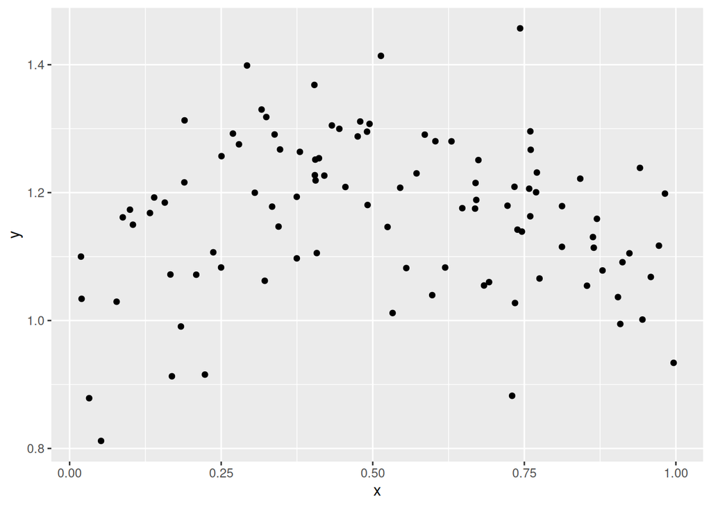

```r
library(ggplot2)
library(dplyr)

ggplot(data = bind_cols(
  x = x,
  y = y
), aes(
  x = x,
  y = y
)) +
  geom_point()
```

There seems to be a nonlinear concave relationship between x and y.

3. (2 points) Use `lm()` to fit 3 models below. Print the summary tables for 3 fitted models and comment on what you find.
- Model I: $Y = \beta_0 + \beta_1 X + \epsilon$
- Model II: $Y = \beta_0 + \beta_1 X + \beta_2 X^2 + \epsilon$
- Model III: $Y = \beta_0 + \beta_1 X + \beta_2 X^2 + \beta_3 X^3 + \epsilon$

```r
library(purrr)

models <- tibble(
  equation = list(
    formula(y ~ x),
    formula(y ~ x + I(x^2)),
    formula(y ~ x + I(x^2) + I(x^3))
  )
)

models <- models %>% mutate(
  fit = map(equation, ~ .x %>% lm()),
  summary = map(fit, ~ .x %>% summary())
)

models$summary
```

```
## [[1]]
##
## Call:
## lm(formula = .)
##
## Residuals:
##      Min       1Q   Median       3Q      Max
## -0.35570 -0.08269  0.01401  0.08742  0.29345
##
## Coefficients:
##              Estimate Std. Error t value Pr(>|t|)
## (Intercept)  1.167787   0.026226  44.528   <2e-16 ***
## x           -0.005891   0.044742  -0.132    0.896
## ---
## Signif. codes:  0 '***' 0.001 '**' 0.01 '*' 0.05 '.' 0.1 ' ' 1
##
## Residual standard error: 0.1216 on 98 degrees of freedom
## Multiple R-squared:  0.0001769,  Adjusted R-squared:  -0.01003
## F-statistic: 0.01734 on 1 and 98 DF,  p-value: 0.8955
##
##
## [[2]]
##
## Call:
## lm(formula = .)
##
## Residuals:
##       Min        1Q    Median        3Q       Max
## -0.304152 -0.057839  0.008669  0.073283  0.275518
##
## Coefficients:
##             Estimate Std. Error t value Pr(>|t|)
## (Intercept)  1.00522    0.03693  27.222  < 2e-16 ***
## x            0.87573    0.16187   5.410 4.54e-07 ***
## I(x^2)      -0.85955    0.15315  -5.613 1.89e-07 ***
## ---
## Signif. codes:  0 '***' 0.001 '**' 0.01 '*' 0.05 '.' 0.1 ' ' 1
##
## Residual standard error: 0.1062 on 97 degrees of freedom
## Multiple R-squared:  0.2453, Adjusted R-squared:  0.2297
```

[output cut: 9 more lines]

```
##       Min        1Q    Median        3Q       Max
## -0.285391 -0.068198  0.009732  0.071038  0.294019
##
## Coefficients:
##             Estimate Std. Error t value Pr(>|t|)
## (Intercept)   0.9502     0.0500  19.006  < 2e-16 ***
## x             1.4608     0.3960   3.688 0.000374 ***
## I(x^2)       -2.2740     0.8884  -2.560 0.012038 *
## I(x^3)        0.9329     0.5773   1.616 0.109388
## ---
## Signif. codes:  0 '***' 0.001 '**' 0.01 '*' 0.05 '.' 0.1 ' ' 1
##
## Residual standard error: 0.1053 on 96 degrees of freedom
## Multiple R-squared:  0.2653, Adjusted R-squared:  0.2423
## F-statistic: 11.55 on 3 and 96 DF,  p-value: 1.565e-06
```

- In the first model x is not significant and the $R^2$ is low.
- In the second model x and $x^2$ are significant and the $R^2$ is higher.
- In the third model x and $x^2$are significant and the $R^2$ increases slightly
4. (2 points) Calculate the leave-one-out-cross-validation mean squared error for each model.

```r
library(magrittr)

train_mse <- function(test_ind, data, equation) {
  train <- data[-test_ind, ]
  test <- data[test_ind, ]

  fit <- lm(formula = equation, data = train)

  pred <- predict(fit, test %>% select(x))
  obs <- test$y
  mse <- sum(obs - pred)^2
  mse
}


CV <- function(x, y, equation, k) {
  set.seed(11152)
  data <- bind_cols(x = x, y = y)
  n <- length(x)

  test_ind <- sample(seq_len(length(x))) %>% split((1:n)%%k)

  test_ind %>%
    map_dbl(~ train_mse(.x, data, equation)) %>%
    mean()
}


models %>%
  mutate(
         test_mse = map_dbl(equation, ~ CV(x, y, .x, 100)),
         equation = format(equation)) %>%
  select(equation, test_mse)
```

```
## # A tibble: 3 × 2
##   equation                test_mse
##   <chr>                      <dbl>
## 1 y ~ x                     0.0152
## 2 y ~ x + I(x^2)            0.0116
## 3 y ~ x + I(x^2) + I(x^3)   0.0116
```

5. (2 points) Calculate the k-fold-cross-validation ($k=10$) mean squared error for each model.

```r
models %>%
  mutate(
         test_mse = map_dbl(equation, ~ CV(x, y, .x, 10)),
         equation = format(equation)) %>%
  select(equation, test_mse)
```

```
## # A tibble: 3 × 2
##   equation                test_mse
##   <chr>                      <dbl>
## 1 y ~ x                     0.0825
## 2 y ~ x + I(x^2)            0.0541
## 3 y ~ x + I(x^2) + I(x^3)   0.0463
```

6. (1 point) Based on your results in (d) and (e), which model has the least cross-validation error? Briefly explain why.

Based on these results we should use the second model since the LOOCV is the same for the second and third model and the second model is less complex.

# Random Number Generation

1. Simulate `N = 1000` binomial random variables $B(n = 10; p = 0.4)$ using three approaches: inversion method, by simulating corresponding Bernoulli random variables by inversion method and using R function `rbinom`. Plot the empirical probability density functions of all three samples on one panel. Comment on the results.

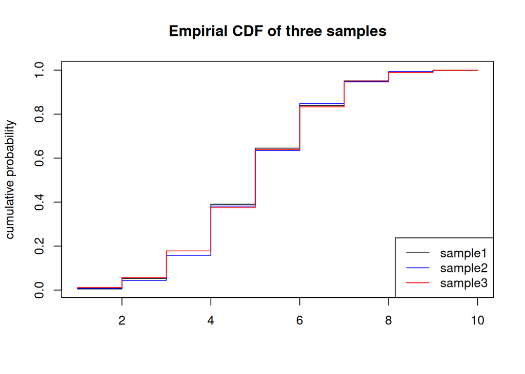

```r
set.seed(11153)

N = 1000; n = 10; p = 0.4
# approach 1
uniforms = runif(N)
sample1 = qbinom(uniforms, n, p)
d1 = cumsum(table(sample1)/N)

# approach 2
uniforms = runif(N * n)
sample2_tmp = matrix(qbinom(uniforms, 1, p), N, n)
sample2 = apply(sample2_tmp, 1, sum)
d2 = cumsum(table(sample2)/N)

# approach 3
sample3 = rbinom(N, n, p)
d3 = cumsum(table(sample3)/N)

plot(d1, main = "Empirial CDF of three samples", xlab = "", ylab = "cumulative probability", type = "s")
lines(d2, col = "blue", type = "s")
lines(d3, col = "red", type = "s")
legend("bottomright", col = c("black", "blue", "red"), lty = 1, legend = paste("sample", 1:3, sep = ""))
```

The results all produce the same results with the exception of some sampling error which will decrease as N increases.

2. The aim is to simulate `N = 10 000` standard normal distributed random variables with density $f(x) = (2\pi)^{-0.5} exp(x^2/2)$ using accept-reject method and a generator for uniform random variables only. As a candidate density g use the density of the standard Cauchy distribution $g(x) = \{\pi(1 + x^2)\}^{-1}$.
- Choose a value of the constant $c$, such that $f(x) \leq cg(x)$.
- Obtain `N` standard normal random variables using the accept-reject method, generating Cauchy distributed random variables using inversion method. Compare estimated and theoretical acceptance probabilities. Plot a histogram of the obtained sample and add the standard normal density to the plot. Make a QQ-plot. Comment on the results.
- Is it possible to simulate from the standard Cauchy density using the accept-reject method with a standard normal candidate density?

```r
g_fun = function(x){return(1/(pi * (1 + x^2)))}
f_fun = function(x){return((2* pi)^(-0.5) * exp(-x^2/2))}
x = seq(-10, 10, 0.01)
gx = g_fun(x)
fx = f_fun(x)
c = max(fx/gx)
c
```

```
## [1] 1.520347
```

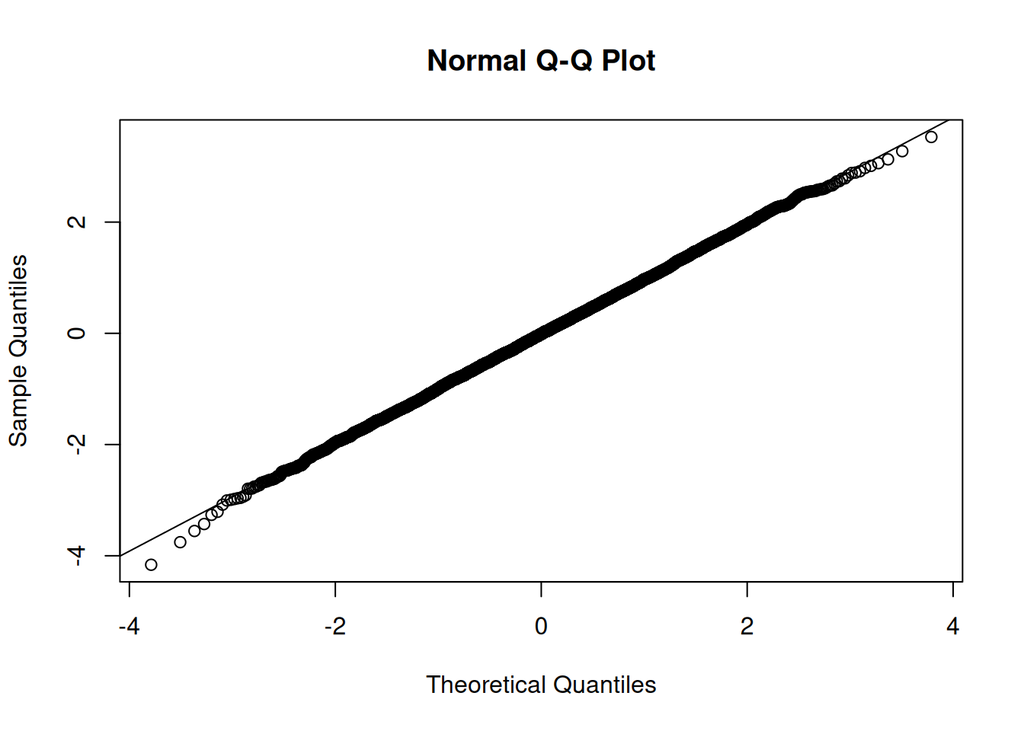

```r
set.seed(11154)
N = 10000

# Step 1 - generating Cauchy distributed random variables using inversion method
uniforms1 = runif(N)
cauchies = qcauchy(uniforms1)

# Step 2 - generating standard normal random variables using the accept-reject method
uniforms2 = runif(N)
accept = uniforms2 * c * g_fun(cauchies) < f_fun(cauchies)
normals = cauchies[accept]

# Step 3 - QQplot
qqnorm(normals)
qqline(normals)
```

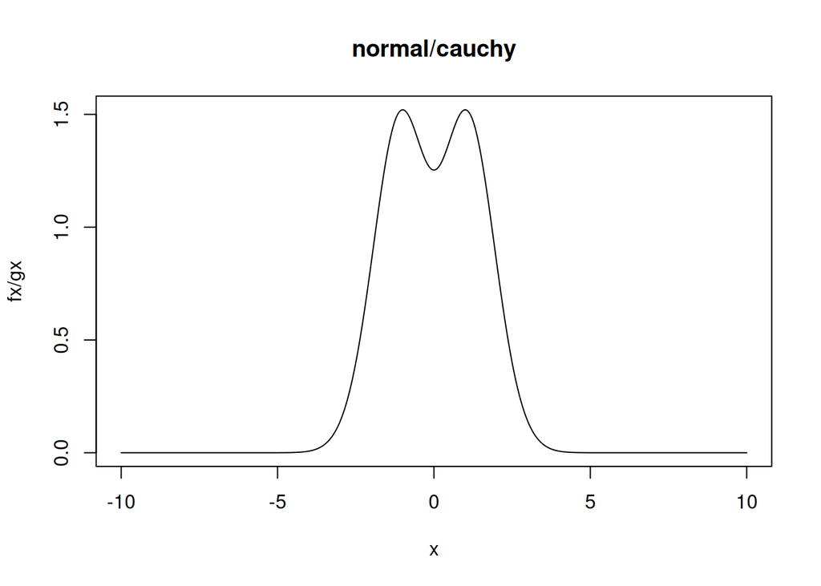

```r
plot(x, fx/gx, type = "l", main = "normal/cauchy")
```

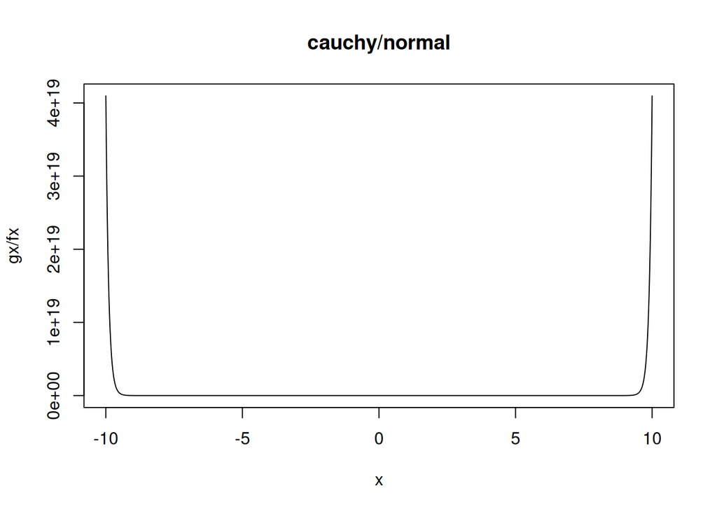

```r
plot(x, gx/fx, type = "l", main = "cauchy/normal")
```

It’s impossible to generate a cauchy distribution using a normal distribution because such c doesn’t exist for all x.